# GDA_Bellabeat_Capstone

Joseph Hernandez

2022-07-02

## Summary

Bellabeat is a high-tech manufacturer of health-focused smart products. Urška Sršen, co-founder and Chief Creative Officer, believes analyzing smart device fitness data could facilitate the companies ability to become larger global market player.

## Ask

### Business Task

Identify opportunities for growth based on smart device data and provide recommendations to steer Bellabeat’s marketing strategy.

### Bellabeat Products

- **Bellabeat app:** provides users with health data related to their activity, sleep, stress, menstrual cycle, and mindfulness habits. This data can help users better understand their current habits and make healthy decisions. The Bellabeat app connects to their line of smart wellness products.
- **Leaf:** Bellabeat’s classic wellness tracker can be worn as a bracelet, necklace, or clip. The Leaf tracker connects to the Bellabeat app to track activity, sleep, and stress.
- **Time:** This wellness watch combines the timeless look of a classic timepiece with smart technology to track user activity sleep, and stress. The Time watch connects to the Bellabeat app to provide you with insights into your daily wellness.
- **Spring:** This is a water bottle that tracks daily water intake using smart technology to ensure that you are appropriately hydrated throughout the day. The Spring bottle connects to the Bellabeat app to track your hydration levels.
- **Bellabeat membership:** Bellabeat also offers a subscription-based membership program for users. Membership gives users 24/7 access to fully personalized guidance on nutrition, activity, sleep, health and beauty, and mindfulness based on their lifestyle and goals

### Guiding Questions

- What are some trends in smart device usage?
- How could these trends apply to Bellabeat customers?
- How could these trends help influence Bellabeat’s marketing strategy?

### Stakeholders

- Urška Sršen - Bellabeat cofounder and Chief Creative Officer
- Sando Mur - Bellabeat cofounder and key member of Bellabeat’s executive team
- Marketing Analytics Team

## Prepare

### Setting Up the Environment

Install packages utilized for analysis

`install.packages("tidyverse")`  
`install.packages("here")`  
`install.packages("skimr")`  
`install.packages("janitor")`  
`install.packages("ggpubr")`  
`install.packages("ggrepel")`  
`install.packages("VennDiagram")`  
`install.packages("png")`  
`install.packages("openair")`  
`install.packages("formattable")`

Load libraries used for analysis

```r
library(tidyverse)
library(here)
library(skimr)
library(janitor)
library(lubridate)
library(ggpubr)
library(ggrepel)
library(readr)
library(scales)
library(VennDiagram)
library(png)
library(openair)
library(formattable)
```

Set working directory

```r
setwd("~/Documents/Code/Projects/gda_fitbit_tracker_da_project")
```

### Import Datasets

Some of the datasets contained repeated data points that were rolled up into a daily_activity data set. Additionally, several datasets had both long and wide versions, only long versions were imported for analysis. The following data sets were utilized to help answer questions related to the business task.

- dailyActivity_merged.csv
- sleepDay_merged.csv
- hourlyCalories_merge.csv
- hourlyIntensities_merged.csv
- hourlySteps_merged.csv
- heartrate_seeconds_merged.csv
- weightLogInfo_merged.csv

```r
daily_activity_all <- read.csv("data/dailyActivity_merged.csv")
daily_sleep <- read.csv("data/sleepDay_merged.csv")
hourly_calories <- read.csv("data/hourlyCalories_merged.csv")
hourly_intensity <- read.csv("data/hourlyIntensities_merged.csv")
hourly_steps <- read.csv("data/hourlySteps_merged.csv")
heartrate_seconds <- read.csv("data/heartrate_seconds_merged.csv")
weight_log <- read.csv("data/weightLogInfo_merged.csv")
```

## Process

This analysis will be done in R due to the amount of data, its ability to easily combine and reshape datasets, and to create data visualizations for presentation. Google Slides will be used to create a presentation for the stakeholders to communicate findings and recommendations.

### Data Cleaning / Transformation

```r
str(daily_activity_all)
```

```
## 'data.frame':    940 obs. of  15 variables:
##  $ Id                      : num  1.5e+09 1.5e+09 1.5e+09 1.5e+09 1.5e+09 ...
##  $ ActivityDate            : chr  "4/12/16" "4/13/16" "4/14/16" "4/15/16" ...
##  $ TotalSteps              : int  13162 10735 10460 9762 12669 9705 13019 15506 10544 9819 ...
##  $ TotalDistance           : num  8.5 6.97 6.74 6.28 8.16 ...
##  $ TrackerDistance         : num  8.5 6.97 6.74 6.28 8.16 ...
##  $ LoggedActivitiesDistance: num  0 0 0 0 0 0 0 0 0 0 ...
##  $ VeryActiveDistance      : num  1.88 1.57 2.44 2.14 2.71 ...
##  $ ModeratelyActiveDistance: num  0.55 0.69 0.4 1.26 0.41 ...
##  $ LightActiveDistance     : num  6.06 4.71 3.91 2.83 5.04 ...
##  $ SedentaryActiveDistance : num  0 0 0 0 0 0 0 0 0 0 ...
##  $ VeryActiveMinutes       : int  25 21 30 29 36 38 42 50 28 19 ...
##  $ FairlyActiveMinutes     : int  13 19 11 34 10 20 16 31 12 8 ...
##  $ LightlyActiveMinutes    : int  328 217 181 209 221 164 233 264 205 211 ...
##  $ SedentaryMinutes        : int  728 776 1218 726 773 539 1149 775 818 838 ...
##  $ Calories                : int  1985 1797 1776 1745 1863 1728 1921 2035 1786 1775 ...
```

```r
str(daily_sleep)
```

```
## 'data.frame':    413 obs. of  5 variables:
##  $ Id                : num  1.5e+09 1.5e+09 1.5e+09 1.5e+09 1.5e+09 ...
##  $ SleepDay          : chr  "4/12/2016 12:00:00 AM" "4/13/2016 12:00:00 AM" "4/15/2016 12:00:00 AM" "4/16/2016 12:00:00 AM" ...
##  $ TotalSleepRecords : int  1 2 1 2 1 1 1 1 1 1 ...
##  $ TotalMinutesAsleep: int  327 384 412 340 700 304 360 325 361 430 ...
##  $ TotalTimeInBed    : int  346 407 442 367 712 320 377 364 384 449 ...
```

```r
str(hourly_calories)
```

```
## 'data.frame':    22099 obs. of  3 variables:
##  $ Id          : num  1.5e+09 1.5e+09 1.5e+09 1.5e+09 1.5e+09 ...
##  $ ActivityHour: chr  "4/12/2016 12:00:00 AM" "4/12/2016 1:00:00 AM" "4/12/2016 2:00:00 AM" "4/12/2016 3:00:00 AM" ...
##  $ Calories    : int  81 61 59 47 48 48 48 47 68 141 ...
```

```r
str(hourly_intensity)
```

```
## 'data.frame':    22099 obs. of  4 variables:
##  $ Id              : num  1.5e+09 1.5e+09 1.5e+09 1.5e+09 1.5e+09 ...
##  $ ActivityHour    : chr  "4/12/2016 12:00:00 AM" "4/12/2016 1:00:00 AM" "4/12/2016 2:00:00 AM" "4/12/2016 3:00:00 AM" ...
##  $ TotalIntensity  : int  20 8 7 0 0 0 0 0 13 30 ...
##  $ AverageIntensity: num  0.333 0.133 0.117 0 0 ...
```

```r
str(hourly_steps)
```

```
## 'data.frame':    22099 obs. of  3 variables:
##  $ Id          : num  1.5e+09 1.5e+09 1.5e+09 1.5e+09 1.5e+09 ...
##  $ ActivityHour: chr  "4/12/2016 12:00:00 AM" "4/12/2016 1:00:00 AM" "4/12/2016 2:00:00 AM" "4/12/2016 3:00:00 AM" ...
##  $ StepTotal   : int  373 160 151 0 0 0 0 0 250 1864 ...
```

```r
str(heartrate_seconds)
```

```
## 'data.frame':    2483658 obs. of  3 variables:
##  $ Id   : num  2.02e+09 2.02e+09 2.02e+09 2.02e+09 2.02e+09 ...
##  $ Time : chr  "4/12/2016 7:21:00 AM" "4/12/2016 7:21:05 AM" "4/12/2016 7:21:10 AM" "4/12/2016 7:21:20 AM" ...
##  $ Value: int  97 102 105 103 101 95 91 93 94 93 ...
```

```r
str(weight_log)
```

```
## 'data.frame':    67 obs. of  8 variables:
##  $ Id            : num  1.50e+09 1.50e+09 1.93e+09 2.87e+09 2.87e+09 ...
##  $ Date          : chr  "5/2/2016 11:59:59 PM" "5/3/2016 11:59:59 PM" "4/13/2016 1:08:52 AM" "4/21/2016 11:59:59 PM" ...
##  $ WeightKg      : num  52.6 52.6 133.5 56.7 57.3 ...
##  $ WeightPounds  : num  116 116 294 125 126 ...
##  $ Fat           : int  22 NA NA NA NA 25 NA NA NA NA ...
##  $ BMI           : num  22.6 22.6 47.5 21.5 21.7 ...
##  $ IsManualReport: chr  "True" "True" "False" "True" ...
##  $ LogId         : num  1.46e+12 1.46e+12 1.46e+12 1.46e+12 1.46e+12 ...
```

Looking at the structure of each dataframe, we identify a couple of cleaning requirments

- The repeated distance columns can be dropped as they will not be used for analysis and to improve computational processing.
- The data from the daily data sets can be combined into one dataframe; and
- The data from the hourly data sets can be combined into one dataframe.
- Date columns needed to be formatted as dates instead of strings
- Day of week can be added to provide an additional way to analyze the data

#### Join daily datasets together

Join daily_sleep with daily_activities

- Need to isolate date and time in daily_sleep
- convert ActivityDate to date to enable use for join criteria

```r
sleep <- daily_sleep %>%
  clean_names() %>%
  separate(col = sleep_day, c("date", "sleep_time"), sep = " ") %>%
  mutate(date = mdy(date), day_week = weekdays(date)) %>%
  rename("sleep_records" = "total_sleep_records",
        "asleep_mins" = "total_minutes_asleep") %>%
  select(-c(sleep_time,total_time_in_bed))
sleep <- sleep[,c(1,2,5,3,4)]
```

```r
daily_activities <- daily_activity_all %>%
  # Add column for total activity minutes and day of week
  mutate(ActivityDate = mdy(ActivityDate), day_week = weekdays(ActivityDate)) %>%
  rowwise() %>%
  mutate(total_active_minutes = sum(c_across(VeryActiveMinutes:LightlyActiveMinutes))) %>%
  rename("date" = "ActivityDate", "total_calories" = "Calories") %>%
  clean_names() %>%
  left_join(sleep, by = c("id", "date", "day_week")) %>%
  select(-c(5:10))
# Reorder columns
daily_activities <- daily_activities[,c(1,2,10,9,3,4,11,5:8,12,13)]
# Remove duplicates
daily_activities <- daily_activities[!duplicated(daily_activities),]
```

Take a deeper look at data fields of combined dataframe

- There are records with either 0 steps taken or 1440 sedentary_minutes. This would indicate that the device was not was not utilized on the given day. Those records are being eliminate skewness in analysis.

```r
# view(daily_activities)
# 84 records removed
daily_activities <- daily_activities[!(daily_activities$total_steps == 0 | daily_activities$sedentary_minutes == 1440),]
```

#### Join hourly datasets together

Join hourly_calories, hourly_intensity, and hourly_steps

```r
hourly_activities <- hourly_calories %>%
  left_join(hourly_intensity, by = c("Id", "ActivityHour")) %>%
  left_join(hourly_steps, by = c("Id", "ActivityHour")) %>%
  clean_names() %>%
  mutate(activity_hour = mdy_hms(activity_hour),
         day_week = weekdays(activity_hour)) %>%
  separate(col = activity_hour, into  = c("date", "time"), sep = " ") %>%
  mutate(date = ymd(date)) %>%
  select(-"average_intensity")
# Reorder columns
hourly_activitities <- hourly_activities[,c(1,2,7,3,6,5,4)]
```

Take a deeper look at data fields of combined dataframe

```r
# view(hourly_activities)
# 84 records removed
hourly_activities <- hourly_activities[!(hourly_activities$step_total == 0),]
```

#### Clean heartrate data

- Group table by user id and date
- Table is has data recorded for every five seconds
- Analysis will not be a deep dive into HR monitoring
- Therefore data can be condensed for higher level usage info

```r
heartrate <- heartrate_seconds %>%
  clean_names() %>%
  mutate(time = mdy_hms(time)) %>%
  separate(col = time, c("date", "time"), sep = " ") %>%
  # group data by id and date
  select(-c(time, value)) %>%
  group_by(id, date) %>%
  summarize(.groups = "drop")
```

#### Clean weight_log

```r
weight_log <- weight_log %>%
  clean_names() %>%
  mutate(date = mdy_hms(date)) %>%
  separate(col = date, into = c("date", "time"), sep = " ") %>%
  mutate(date = ymd(date)) %>%
  select(-"log_id")
```

Check to ensure date range matches across dataframes

```r
min_date <- min(daily_activities$date)
print(min_date)
```

```
## [1] "2016-04-12"
```

```r
min(daily_activities$date) == min(hourly_activities$date) &&
+ min(daily_activities$date) == min(sleep$date) &&
+ min(daily_activities$date) == min(heartrate$date)
```

```
## [1] TRUE
```

```r
max_date <- max(daily_activities$date)
print(max_date)
```

```
## [1] "2016-05-12"
```

```r
max(daily_activities$date) == max(hourly_activities$date) &&
+ max(daily_activities$date) == max(sleep$date) &&
+ max(daily_activities$date) == max(heartrate$date)
```

```
## [1] TRUE
```

## Analyze

### Exploritory Data Analysis

#### Idenify user usage by category

- There are 33 users represented in the data

```r
user_count <- 33
usage_type_df <- data.frame("steps" = n_unique(daily_activities$id),
                            "heartrate" = n_unique(heartrate$id),
                            "sleep" = n_unique(sleep$Id),
                            "weight" = n_unique(weight_log$id)) %>%
  mutate("steps_pct" = percent(steps/user_count),
         "heartrate_pct" = percent(heartrate/user_count),
         "sleep_pct" = percent(sleep/user_count),
         "weight_pct" = percent(weight/user_count)
  )
# Reorder columns
usage_type_df <- usage_type_df[,c(1,5,2,6,3,7,4,8)]
usage_type_df
```

[output not shown]

#### Identify Feauture Usagage

- Estabish unique Ids for each activiity
- Create a Venn Diagram to show interseciton of activities

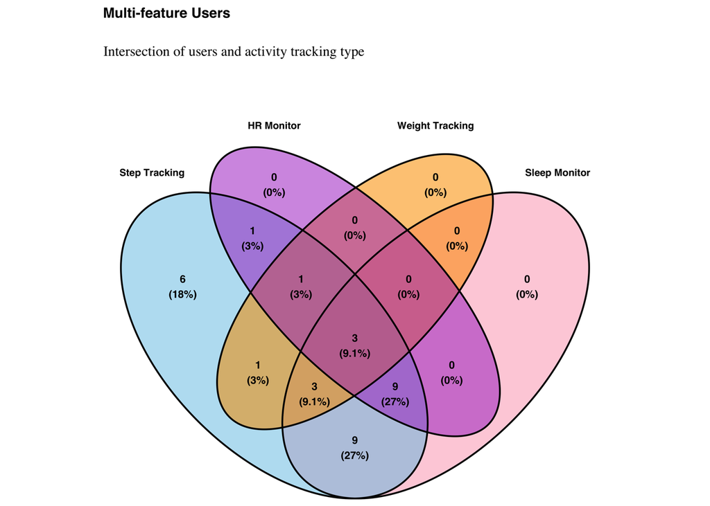

```r
# Generate 4 sets of unique Ids for each activity
step_ids <- unique(daily_activities$id, incomparables = FALSE)
sleep_ids <- unique(sleep$id, incomparables = FALSE)
heartrate_ids <- unique(heartrate$id, incomparables = FALSE)
weight_ids <- unique(weight_log$id, incomparables = FALSE)

# Plot
venn <- venn.diagram(x = list(step_ids, sleep_ids, heartrate_ids, weight_ids),
  category.names = c("Step Tracking", "Sleep Monitor", "HR Monitor", "Weight Tracking"),
  main = "Multi-feature Users",
  main.pos = c(0.11, 1.05),
  main.fontface = "bold",
  main.fontfamily = "sans",
  sub = "Intersection of users and activity tracking type",
  sub.pos = c(0.25, 1.05),
  filename = "images/activities_venn.png",
  print.mode = c("raw","percent"),
  sigdigs = 2,
  output=TRUE,
  imagetype="png",
  lwd = 2,
  fill = c("skyblue", "pink1", "mediumorchid", "orange"),
  cex = .75,
  fontface = "bold",
  fontfamily = "sans",
  cat.cex = .7,
  cat.fontface = "bold",
  cat.default.pos = "outer",
  cat.fontfamily = "sans")

# Read plot image
img <- readPNG("images/activities_venn.png")
grid::grid.raster(img)
```

**Single-feature usage:**

- Step counting feature was utilized by all users
- **18%**, 6 Users, only utilized the the *Step Tracking* feature

**Multi-feature usage:**

Feature combinations:

- **73%**, 24 Users, utilized *Step Tracking* and **Sleep Monitor*** features
- **42%**, 14 Users, utilized *Step Tracking* and *Heart Rate Monitor* features
- **24%**, 8 Users, utilized *Step Tracking* and *Weight Tracking* features

Two feature only combinations:

- **33%**, 11 Users, utilized only two features
- **27%**, 9 Users, utilized *Step Tracking* and **Sleep Monitor***
- **3%**, 1 User, utilized *Step Tracking* and *Heart Rate Monitor*
- **3%**, 1 User, utilized *Step Tracking* and *Weight Tracking*

Three feature only combinations:

- **39%**, 13 Users, utilized only three features
- **27%**, 9 Users, utilized *Step Tracking* and **Sleep Monitor*** and *Heart Rate Monitor* features
- **9%**, 3 User, utilized *Step Tracking* and **Sleep Monitor*** and *Weight Tracking* features
- **3%**, 1 User, utilized *Step Tracking* and *Heart Rate Monitor* and *Weight Tracking* features

#### Identifying Trends

Looking for daily usage trends

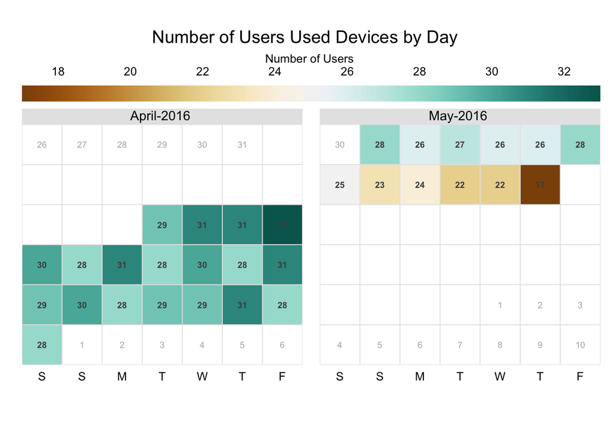

```r
# Get number of users used their devices each day:
obs_users <- daily_activities %>% group_by(date, day_week) %>%
  summarize(user_perday = sum(n()), .groups = "drop") %>%
  mutate(date = as.POSIXct(paste(as.character(date), "00:00:00")))

#Plot a calendar heat map on users per day
calendarPlot(obs_users, pollutant = "user_perday", year = 2016, month = 4:5,  cex.lim = c(0.6, 1),
             main = "Number of Users Used Devices by Day", cols= openColours(scheme = "BrBG"),
             key.header = "Number of Users", key.position = "top", annotate = c("value"), font.lim = c(2,1))
```

```r
options(repr.plot.width = 14, repr.plot.height = 10)
```

Creating a dataframe to isolate step_count and sleep data, the most utilized features.

- Remove records with N/A values for sleep in *daily_activities* dataframe

```r
step_sleep_df <- daily_activities[complete.cases(daily_activities),]
# Check data
head(step_sleep_df)
```

```
## # A tibble: 6 × 13
## # Rowwise:
##           id date       day_week  total_calories total_steps total_distance
##        <dbl> <date>     <chr>              <int>       <int>          <dbl>
## 1 1503960366 2016-04-12 Tuesday             1985       13162           8.5
## 2 1503960366 2016-04-13 Wednesday           1797       10735           6.97
## 3 1503960366 2016-04-15 Friday              1745        9762           6.28
## 4 1503960366 2016-04-16 Saturday            1863       12669           8.16
## 5 1503960366 2016-04-17 Sunday              1728        9705           6.48
## 6 1503960366 2016-04-19 Tuesday             2035       15506           9.88
## # … with 7 more variables: total_active_minutes <int>,
## #   very_active_minutes <int>, fairly_active_minutes <int>,
## #   lightly_active_minutes <int>, sedentary_minutes <int>, sleep_records <int>,
## #   asleep_mins <int>
```

```r
nrow(step_sleep_df)
```

```
## [1] 410
```

```r
n_unique(step_sleep_df$id)
```

```
## [1] 24
```

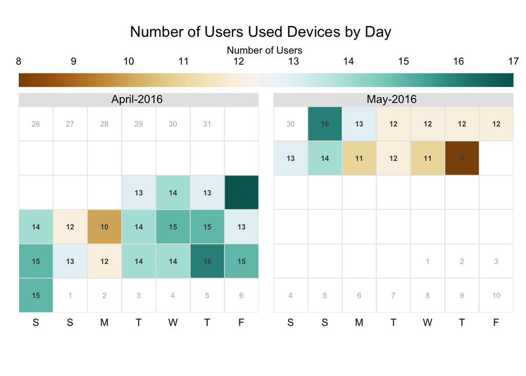

```r
# Get number of users used their devices each day:
top_feature_obs_users <- step_sleep_df %>% group_by(date, day_week) %>%
  summarize(user_perday = sum(n()), .groups = "drop") %>%
  mutate(date = as.POSIXct(paste(as.character(date), "00:00:00")))

#Plot a calendar heat map on step & sleep users per day
calendarPlot(top_feature_obs_users, pollutant = "user_perday", year = 2016, month = 4:5,  cex.lim = c(0.6, 1),
             main = "Number of Users Used Devices by Day", cols= openColours(scheme = "BrBG"),
             key.header = "Number of Users", key.position = "top", annotate = c("value"), font.lim = c(2,1))
```

```r
options(repr.plot.width = 14, repr.plot.height = 10)
```

See if there is variance in which days of the week see more usage

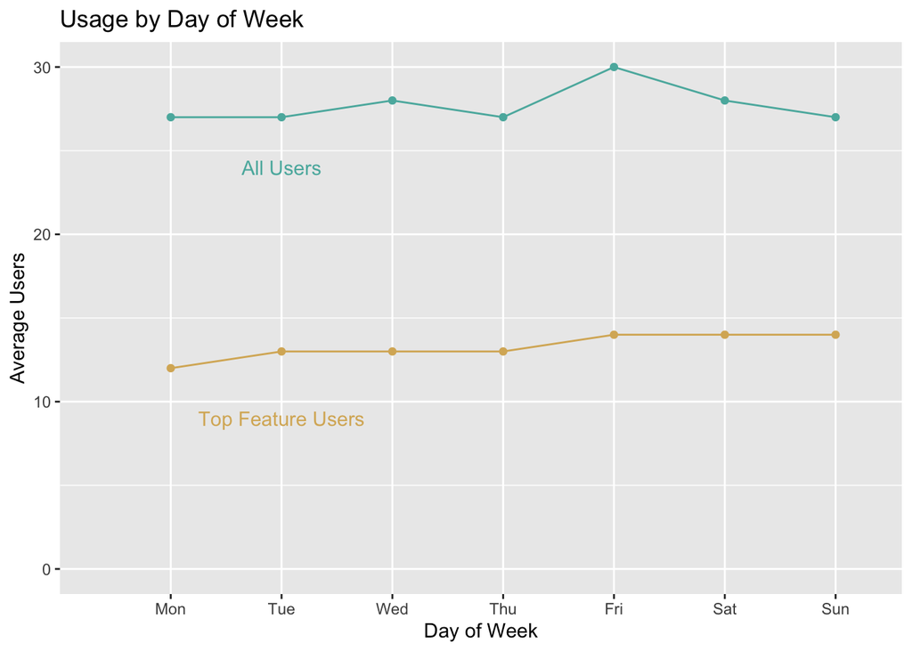

```r
use_day_week <- merge(obs_users, top_feature_obs_users, by = c("date", "day_week")) %>%
  select(-c(date)) %>%
  group_by(day_week) %>%
  rename("all_activity_use" = user_perday.x, "step_sleep_use" = user_perday.y) %>%
  summarise(daily_avg_all = round(mean(all_activity_use),0), daily_avg_step_sleep = round(mean(step_sleep_use),0))

use_day_week$day_week <- ordered(use_day_week$day_week, levels=c("Monday", "Tuesday", "Wednesday", "Thursday",
                                                                 "Friday", "Saturday", "Sunday"))

ggplot(data = use_day_week, aes(x = ordered(substr(day_week,0,3), levels=c("Mon","Tue","Wed","Thu","Fri",
                                                                           "Sat","Sun")))) +
  geom_line(mapping = aes(y=daily_avg_all, group=1), color = rgb(90,180,172, maxColorValue = 255)) +
  geom_point(mapping = aes( y=daily_avg_all), color = rgb(90,180,172, maxColorValue = 255))  +
  geom_line(mapping = aes(y=daily_avg_step_sleep, group=2), color = rgb(216,179,101, maxColorValue = 255))  +
  geom_point(mapping = aes(y=daily_avg_step_sleep), color = rgb(216,179,101, maxColorValue = 255)) +
  annotate("text", label = "All Users", x = 2, y = 24, color = rgb(90,180,172, maxColorValue = 255)) +
  annotate("text", label = "Top Feature Users", x = 2, y = 9, color = rgb(216,179,101, maxColorValue = 255)) +
  expand_limits(x = 0, y = 0) +
  labs(x="Day of Week", y="Average Users", title = "Usage by Day of Week")
```

Find the average usage per user per day - break user into groups by amount of days of data recorded (‘High’, ‘Medium’, ‘Low’) - find percentage of each category

```r
# Find number of day user used device
user_days_df <- daily_activities %>%
  group_by(id) %>%
  summarize(num_daysused = sum(n()), .groups = "drop") %>%
  arrange(-num_daysused)

# Create category buckets
usage_bucket_df <- user_days_df %>%
  mutate(user_type = case_when(
    between(num_daysused, 1, 10) ~ "Low Usage",
    between(num_daysused, 11, 20) ~ "Medium Usage",
    between(num_daysused, 21, 31) ~ "High Usage",
    TRUE ~ NA_character_)
  )

# Combine new categories to original data_frame
daily_activity_categories <- daily_activities %>%
  left_join(usage_bucket_df, by = "id")

# Get percentage for each user_group
user_group_pct <- usage_bucket_df %>%
  mutate(user_type = fct_relevel(user_type, c("High Usage",
                                              "Medium Usage",
                                              "Low Usage"))) %>%
  group_by(user_type) %>%
  summarize(num_users = n()) %>%
  mutate(percentage = percent(num_users/sum(num_users)))
```

Create same type of dataframe from top feature users

```r
# Find number of day user used device
step_sleep_days_df <- step_sleep_df %>%
  group_by(id) %>%
  summarize(num_daysused = sum(n()), .groups = "drop") %>%
  arrange(-num_daysused)

# Create category buckets
step_sleep_usage_bucket_df <- step_sleep_days_df %>%
  mutate(user_type = case_when(
    between(num_daysused, 1, 10) ~ "Low Usage",
    between(num_daysused, 11, 20) ~ "Medium Usage",
    between(num_daysused, 21, 31) ~ "High Usage",
    TRUE ~ NA_character_)
  )

# Combine new categories to original data_frame
step_sleep_categories <- step_sleep_df %>%
  left_join(usage_bucket_df, by = "id")

# Get percentage for each user_group
step_sleep_group_pct <- step_sleep_usage_bucket_df %>%
  mutate(user_type = fct_relevel(user_type, c("High Usage",
                                              "Medium Usage",
                                              "Low Usage"))) %>%
  group_by(user_type) %>%
  summarize(num_users = n()) %>%
  mutate(percentage = percent(num_users/sum(num_users)))
```

```r
# Set custom colors
grey <- "#e0e0e0"
tan <- "#d8b365"
dgrey <- "#525252"

# Define color_tile_color function
 color_tile_color <- function (...) {
  formatter("span", style = function(x) {
    style(display = "block",
          padding = "0 3px",
          `font.weight` = "bold",
          `border-radius` = "3px",
          `background-color` = ifelse(x == max(x) , tan, grey)) # Remember to change the colors!
  })}

# Use it just like color_tile but without colors
formattable(user_group_pct, align=c("l", "c", "c"),list(
  user_type = formatter("span", style = ~ style(color=dgrey, font.weight="bold")),
  num_users=color_tile_color(),
  percentage=color_tile_color()
  )
)
```

| user_type | num_users | percentage |
| --- | --- | --- |
| High Usage | 25 | 75.76% |
| Medium Usage | 7 | 21.21% |
| Low Usage | 1 | 3.03% |

Identify Trends in Activity Times by User Groups

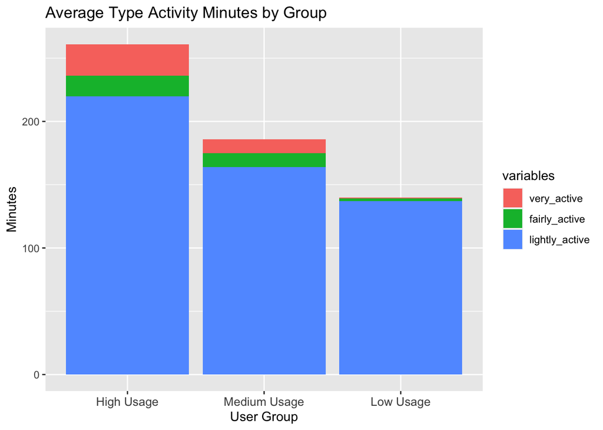

```r
group_activity <-  daily_activity_categories %>%
  group_by(user_type) %>%
  summarize(very_active = round(mean(very_active_minutes), 0),
            fairly_active = round(mean(fairly_active_minutes), 0),
            lightly_active = round(mean(lightly_active_minutes), 0),
            .groups = "drop")

# Reshape data from wide to long for stacked bar chart
group_activity_long <- gather(data = group_activity, key = "variables", value = "value", -user_type) %>%
  mutate(user_type = fct_relevel(user_type, c("High Usage",
                                              "Medium Usage",
                                              "Low Usage")),
                                 variables = fct_relevel(variables, c("very_active",
                                                                      "fairly_active",
                                                                      "lightly_active"
                                                                      )
                                                         )
                                 )

# Plot activity minutes per day by group

group_activity_long %>%
  ggplot() +
  geom_col(aes(x=user_type, y=value, group=variables, fill=variables)) +
  theme(axis.text.x = element_text(size = 10)) +
  labs(x= "User Group", y="Minutes") +
  ggtitle("Average Type Activity Minutes by Group")
```

```r
options(repr.plot.width = 8, repr.plot.height = 5)
```

Identify trends in Activity Minutes by Day of Week

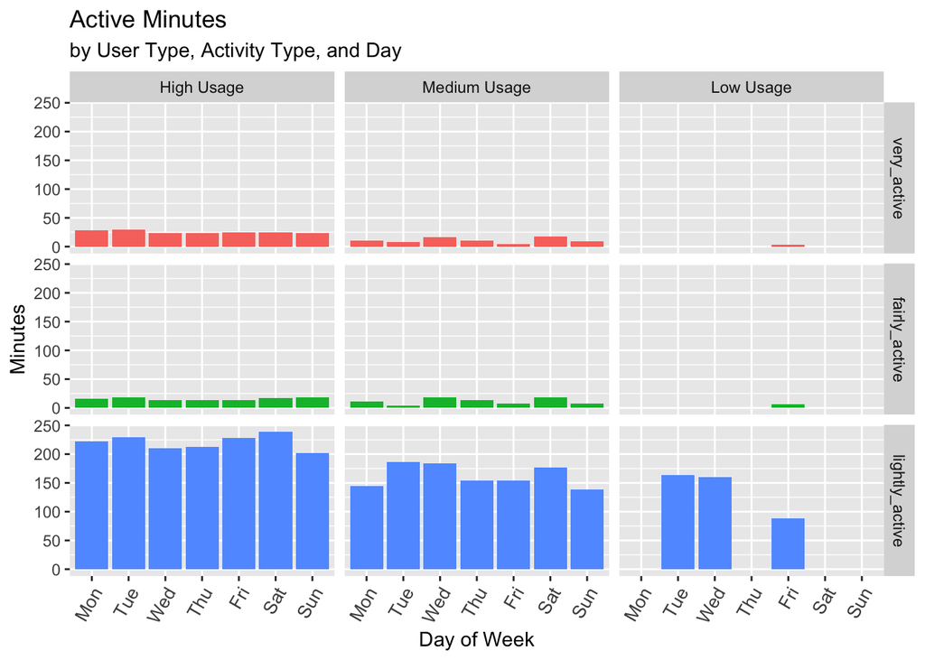

```r
group_activity2 <- daily_activity_categories %>%
  group_by(day_week, user_type) %>%
  mutate(day_week = substr(day_week,0,3)) %>%
  summarize(very_active = round(mean(very_active_minutes), 0),
            fairly_active = round(mean(fairly_active_minutes), 0),
            lightly_active = round(mean(lightly_active_minutes), 0),
            .groups = "drop")

# Reshape data from wide to long
group_activity2_long <- gather(data = group_activity2, key = "variables", value = "value", -c(user_type,day_week)) %>%
  mutate(user_type = fct_relevel(user_type, c("High Usage", "Medium Usage", "Low Usage")
                                 ),
         variables = fct_relevel(variables, c("very_active", "fairly_active", "lightly_active")
                                 ),
         day_week = fct_relevel(day_week, c("Mon", "Tue", "Wed", "Thu", "Fri", "Sat", "Sun")
                                )
         )

# Plot facet_grid
group_activity2_long %>%
  ggplot() +
  geom_col(aes(x=day_week, y=value, fill=variables)) +
  theme(axis.text.x = element_text(size = 10, angle = 60, hjust = 1, vjust = 1)) +
  labs(x="Day of Week", y="Minutes") +
  ggtitle("Active Minutes", "by User Type, Activity Type, and Day") +
  facet_grid(variables~user_type) +
  theme(legend.position="none")
```

```r
options(repr.plot.width = 14, repr.plot.height = 6)
```

- High Usage users have more consistent levels of activity through out the week
- Low Usage users did not record many fairly or very active minutes
- Low Usage minutes had no activity recorded on weekends

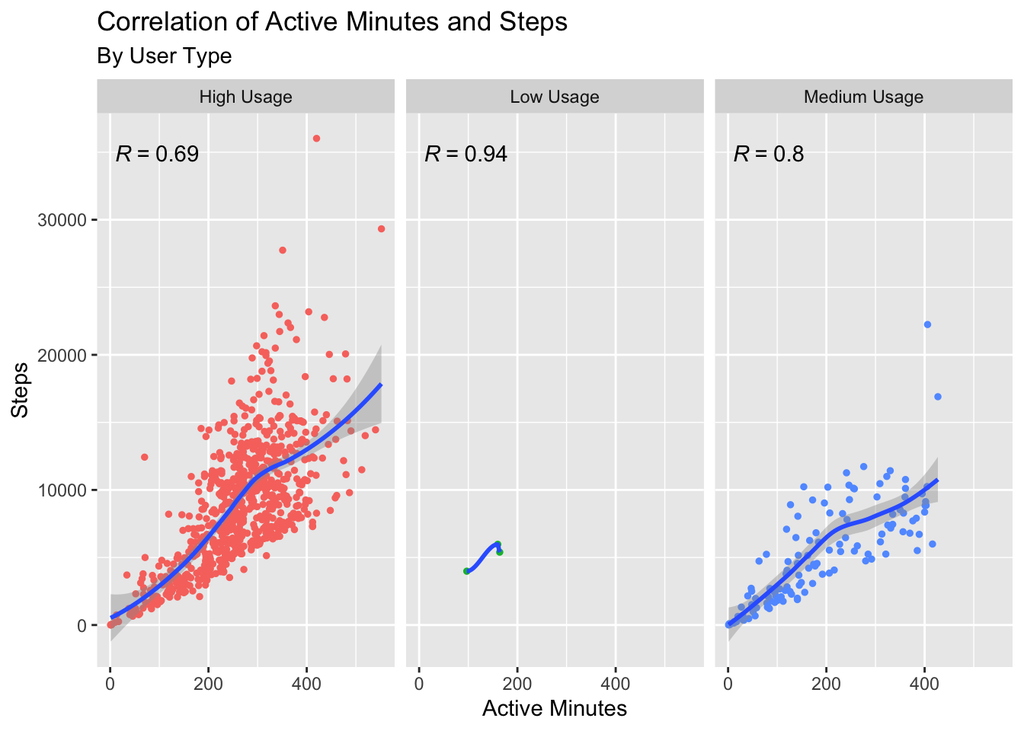

```r
ggplot(data = daily_activity_categories, aes(x=total_active_minutes, y=total_steps)) +
  geom_point(size = 1, aes(color=user_type)) +
  geom_smooth(method='loess', formula=y ~ x) +
  stat_cor(aes(label= ..r.label..), label.x = 10) +
  facet_wrap(~user_type) +
  labs(x="Active Minutes", y="Steps") +
  ggtitle("Correlation of Active Minutes and Steps", "By User Type") +
  theme(legend.position="none")
```

```r
options(repr.plot.width = 14, repr.plot.height = 8)
```

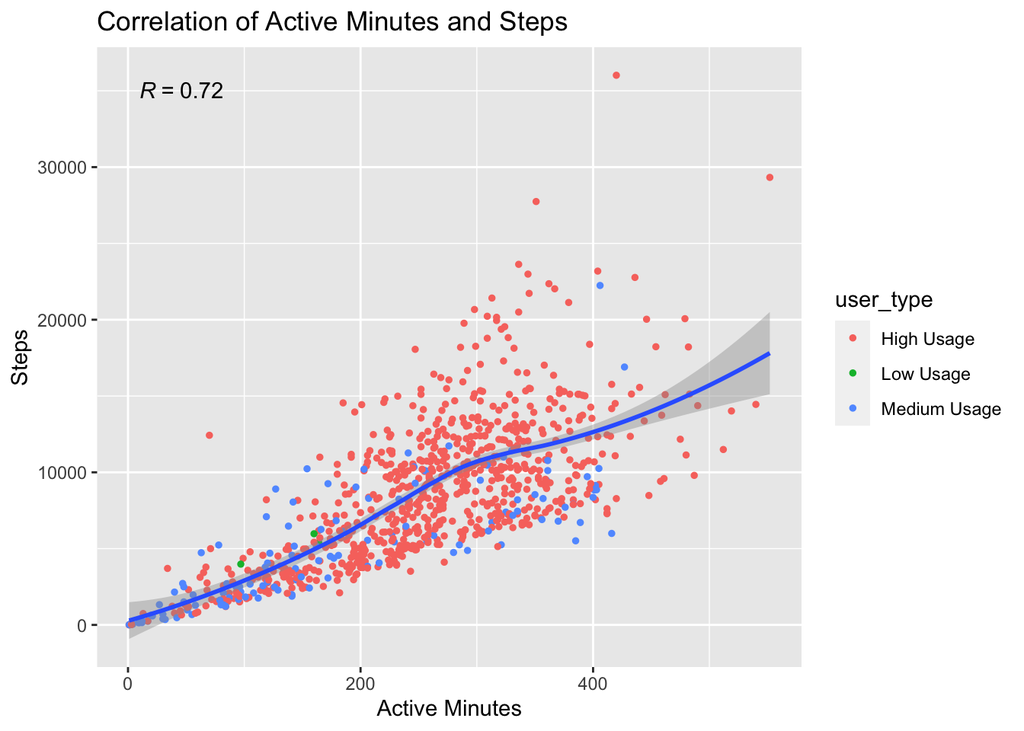

```r
ggplot(data = daily_activity_categories, aes(x=total_active_minutes, y=total_steps)) +
  geom_point(size = 1, aes(color=user_type)) +
  geom_smooth(method='loess', formula=y ~ x) +
  stat_cor(aes(label= ..r.label..), label.x = 10) +
  labs(x="Active Minutes", y="Steps") +
  ggtitle("Correlation of Active Minutes and Steps")
```

```r
options(repr.plot.width = 14, repr.plot.height = 8)
```

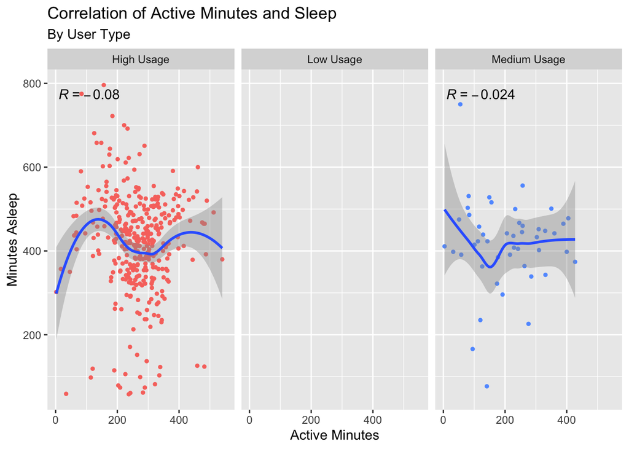

```r
ggplot(data = daily_activity_categories, aes(x=total_active_minutes, y=asleep_mins)) +
  geom_point(size = 1, aes(color=user_type)) +
  geom_smooth(method='loess', formula=y ~ x) +
  stat_cor(aes(label= ..r.label..), label.x = 10) +
  facet_wrap(~user_type) +
  labs(x="Active Minutes", y="Minutes Asleep") +
  ggtitle("Correlation of Active Minutes and Sleep", "By User Type") +
  theme(legend.position="none")
```

```r
options(repr.plot.width = 14, repr.plot.height = 8)
```

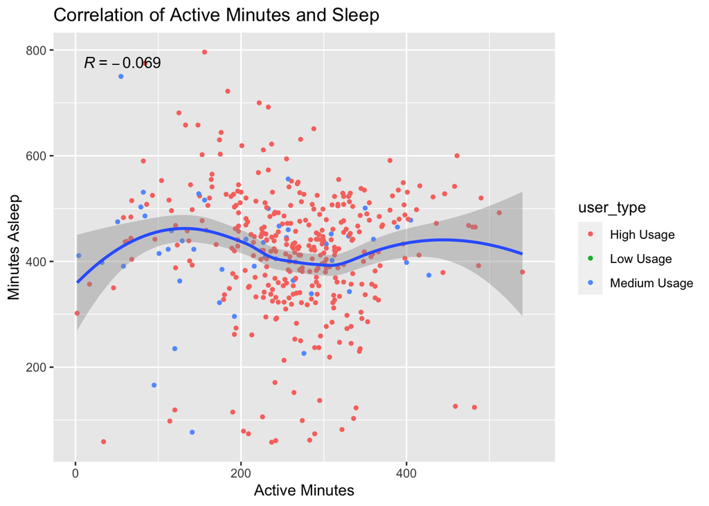

```r
ggplot(data = daily_activity_categories, aes(x=total_active_minutes, y=asleep_mins)) +
  geom_point(size = 1, aes(color=user_type)) +
  geom_smooth(method='loess', formula=y ~ x) +
  stat_cor(aes(label= ..r.label..), label.x = 10) +
  labs(x="Active Minutes", y="Minutes Asleep") +
  ggtitle("Correlation of Active Minutes and Sleep")
```

```r
options(repr.plot.width = 14, repr.plot.height = 8)
```

[figure not shown]

```r
ggplot(data = daily_activity_categories, aes(x=total_active_minutes, y=total_calories)) +
  geom_point(size = 1, aes(color=user_type)) +
  geom_smooth(method='loess', formula=y ~ x) +
  stat_cor(aes(label= ..r.label..), label.x = 10) +
  facet_wrap(~user_type) +
  labs(x="Active Minutes", y="Minutes Asleep") +
  ggtitle("Correlation of Active Minutes and Calories", "By User Type") +
  theme(legend.position="none")
```

```r
options(repr.plot.width = 14, repr.plot.height = 8)
```

[figure not shown]

```r
ggplot(data = daily_activity_categories, aes(x=total_active_minutes, y=total_calories)) +
  geom_point(size = 1, aes(color=user_type)) +
  geom_smooth(method='loess', formula=y ~ x) +
  stat_cor(aes(label= ..r.label..), label.x = 10) +
  labs(x="Active Minutes", y="Minutes Asleep") +
  ggtitle("Correlation of Active Minutes and Calories")
```

```r
options(repr.plot.width = 14, repr.plot.height = 8)
```

## Recommendations (Act)

Currently, Step tracking and Sleep Monitoring are the biggest features utilized by Bellabeat users. Only 9% of the users tracked all four features associated with the data. The feature least used was weight tracking.

The users can be broken down into three categories: High, Medium, and Low Usage. The amount of activity minutes and level of intensity minutes are directly correlated to the usage group. Of note is that activity tracking seems to taper off in the last week of data.

### Marketing

- To promote growth the target population should be the low usage users. The other usage groups utilized their devices consistently.
- Advertising the benefits of active lifestyle
- Promote the weight tracking feature and integrate it with all devices

### Consumer Engagement / Interaction

- Smartphone and device reminders, achievements, and goal tracking can promote more increased device use and encourage users to stay consistent with activity tracking.
- Fitness activity social networking ability integration will encourage increased device usage through group settings and accountability partnering.
- Bellabeat community challenges. Create weekly, monthly, or annual challenges for activities such as steps, distance, total activity, etc..

### Product Extension

- Incorporating a smart weight scale into the product line can present opportunity for increased feature usage and further goal achievement.
  - Manually having to input daily or weekly weight information can be considered an additional burden and deter user from utilizing the feature.
  - Automating data transfer from a smart scale and integrating it with other smart devices and the Bellabeat application can enhance the overall device ecosystem.

### Further Research

- Survey current users about weight tracking usage and their reception of utilizing a smart scale for weight tracking.
- Survey current users for ideas for challenges and types of reminders that would be beneficial to their goals and needs.